# Results

## Participants

Over the pre-specified study period, 12099 patients were included in the the KUH trauma care quality database and subsequently in this study. Of those, 5214 (43.09%) patients were aged >14, had sufficient data on our outcome measure and went on to form the study population (see Figure 1). Participants were then divided into the cohorts blunt multisystem (n=463), geriatric (n=1020), penetrating (n= 183), severe TBI (n=102) and shock (n=170). 41 patients lacked data about emergency department gcs and 12 patients lacked data about emergency department blood pressure. No patients lacked data about dominant injury type or age (see Table 1).

[figure not shown]

SweTrau flowchart

**Figure 1: Exclusion flowchart.** Excluded are all patients patients treated between 2013 and 2017, as they systematically lack data about OFI in addition to other relevant data points. Furthermore, excluded are patients aged 14 and below. TBI: traumatic brain injury.

**Missing data by cohort.** In table 1, the variable ´Category´ refers to the category of data required to group patients into a specified cohort. `Missing` refers to the number of patients lacking sufficient data in said category

| Cohort | Type | Missing | % |
| --- | --- | --- | --- |
| Blunt multisystem | Dominant injury | 0 | 0.00 |
| Penetrating | Dominant injury | 0 | 0.00 |
| Severe TBI | ED GCS | 41 | 0.79 |
| Shock | ED SBP | 12 | 0.23 |
| Geriatric | Age | 0 | 0.00 |

ED SBP: emergency department systolic blood pressure, ED GCS: emergency department Glasgow coma scale.

## Descriptive data

**Table 2: Demographics**

[output not shown]

SD: standard deviation, ED SBP: emergency department systolic blood pressure, ED GCS: emergency department glasgow coma scale, NISS: new injury severity score Survival: survival status 30 days post admission to emergency department.

## Incidence

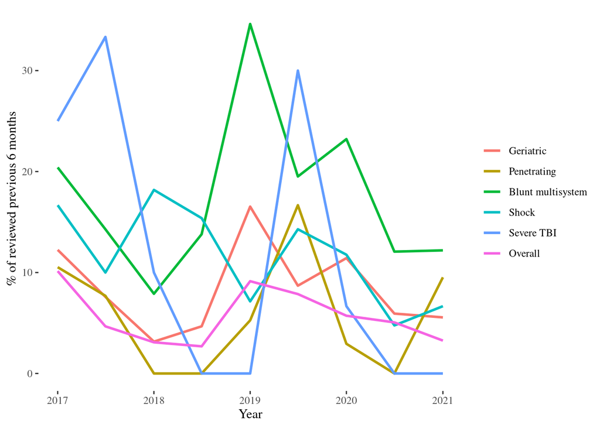

**Figure 2: Biannual OFI incidence.** Percentage of cohort participants with OFI review biannually. OFI: opportunities for improvement, TBI: traumatic brain injury.

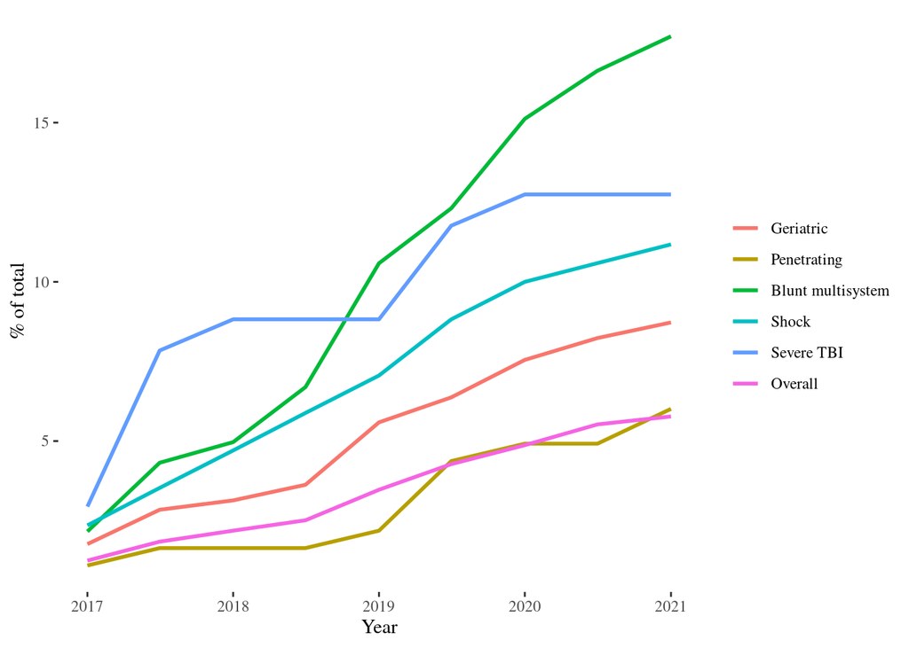

**Figure 3: Cumulative OFI incidence.** Cumulative percentage of total cohort participants with OFI. OFI: opportunities for improvement, TBI: traumatic brain injury.

## Trends

**Table 3: Incidence trends**

| Cohort | Estimate | Standard error | Statistic | P value |
| --- | --- | --- | --- | --- |
| Severe TBI | -0.0161374 | 0.0085940 | -1.8777593 | 0.1025028 |
| Shock | -0.0063567 | 0.0027144 | -2.3417889 | 0.0517086 |
| Overall | -0.0014513 | 0.0019877 | -0.7301489 | 0.4890082 |
| Geriatric | -0.0010150 | 0.0032094 | -0.3162653 | 0.7610232 |
| Penetrating | -0.0004157 | 0.0043651 | -0.0952335 | 0.9267983 |
| Blunt multisystem | -0.0002843 | 0.0060453 | -0.0470252 | 0.9638066 |

TBI: traumatic brain injury, CI: confidence interval.